# CSE 142 Homework 5, Spring 2025

## 60 pts, due: June 5th, 2025

```
Your name: Liam Youm          Your Username: tyoum@ucsc.edu
```

## Instruction

- Submit your assignments onto **Canvas** by the due date. Upload a `zip` file containing:

  (1) The saved/latest `.ipynb` file, please **rename this file with your name included**.

  (2) Also save your file into a pdf version, if error appears, save an html version instead (easier to grade for written questions).

  **For assignment related questions, please reach the course staff through discord or email.**
- This is an **individual** assignment. All help from others (from the web, books other than text, or people other than the TA or instructor) must be clearly acknowledged.

# Neural Networks

Consider the following neural network:

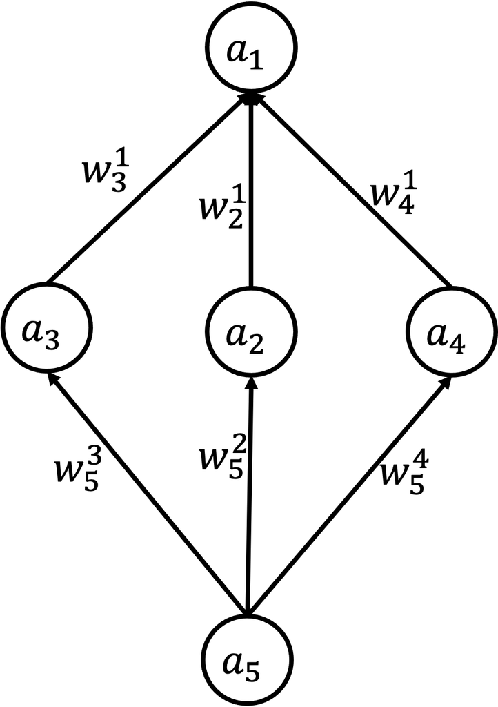

```python
from IPython.display import Image

Image(filename='simple_nn.png', width=400)
```

where $a_i = \Sigma_j w_j^i z_j$ , $z_i = f_i(a_i)$ for $i= 1, 2,3,4, z_5 = a_5$ (an input neuron), and $f_1(x) = f_2(x) = f_3(x) = f_4(x) = $ sigmoid$(x)$.

### Part A

(a) Write a function (in math) to simulate the neural network calculating its output.

\begin{align*} z_5 &= a_5 \\ a_2 &= w^2_5 \cdot a_5 \\ z_2 &= sigmoid(a_2) \\ a_3 &= w^3_5 \cdot a_5 \\ z_3 &= sigmoid(a_3) \\ a_4 &= w^4_5 \cdot a_5 \\ z_4 &= sigmoid(a_4) \\ a_1 &= w^1_2 \cdot z_2 + w^1_3 \cdot z_3 + w^1_4 \cdot z_4 \\ z_1 &= sigmoid(a_1) \\ \end{align*}

(put your math as embedded latex, or otherwise neatly formatted here)

### Part b

(b) Deduce the equation to calculate $δ_i$ (the error value per neuron) for all the neurons. Write a function that given a training sample and the weights of the network calculate $δ_i$ for each neuron.

**Hint:**

#### SIGMOID

$$f(x) = \dfrac{1}{1+e^{-x}} $$$$df(x)/dx = f(x)(1-f(x))$$

#### LOSS FUNCTION

$$error = 0.5*(target - z_1)^2$$

###### #

**Equations for** $δ_i$ *(error per neuron)*

$$ \delta_1 = (-\text{target} + z_1) \cdot z_1 (1 - z_1) $$$$ \delta_i = z_i (1 - z_i) \cdot w^i_1 \cdot \delta_1 \quad \text{for } i = 2, 3, 4 $$$$ \delta_5 = \delta_2\cdot w^2_5 + \delta_3\cdot w^3_5 + \delta_4\cdot w^4_5 $$

**Function: compute_deltas(( a_5 ), target, weights)**

$$ \begin{aligned} a_2 &= w^2_5 \cdot a_5, \quad z_2 = \sigma(a_2) \\ a_3 &= w^3_5 \cdot a_5, \quad z_3 = \sigma(a_3) \\ a_4 &= w^4_5 \cdot a_5, \quad z_4 = \sigma(a_4) \\ a_1 &= w^1_2 \cdot z_2 + w^1_3 \cdot z_3 + w^1_4 \cdot z_4, \quad z_1 = \sigma(a_1) \\ \\ \delta_1 &= (-\text{target} + z_1) \cdot z_1 (1 - z_1) \\ \delta_2 &= z_2 (1 - z_2) \cdot w^2_1 \cdot \delta_1 \\ \delta_3 &= z_3 (1 - z_3) \cdot w^3_1 \cdot \delta_1 \\ \delta_4 &= z_4 (1 - z_4) \cdot w^4_1 \cdot \delta_1 \\ \delta_5 &= \delta_2\cdot w^2_5 + \delta_3\cdot w^3_5 + \delta_4\cdot w^4_5 \end{aligned} $$

Where $\sigma(x) = \frac{1}{1 + e^{-x}}$ is the sigmoid activation function.

### Part c

(c) Assuming that the weight matrix is:

\begin{array}{c|cccc} & 1 & 2 & 3 & 4 \\ \hline 2 & 3 & & & \\ 3 & -4 & & \\ 4 & -1 & & & \\ 5 & & -3 & 2 & -10 \end{array}

use the functions from items (a) and (b) to calculate the output of each neuron, $z_i$, and the error, $δ_i$, for the following training samples:

\begin{array}{ c c } x & y \\ 0.0 & 0.5 \\ 1.0 & 0.1 \end{array}

### Forward and Backward Pass Results

#### Outputs $z_i$ and Errors $\delta_i$ per Neuron

| Input / Target | $z_2$ | $z_3$ | $z_4$ | $z_1$ | $\delta_2$ | $\delta_3$ | $\delta_4$ | $\delta_1$ | $\delta_5$ |
| --- | --- | --- | --- | --- | --- | --- | --- | --- | --- |
| $x = 0.0,\ y = 0.5$ | 0.5000 | 0.5000 | 0.5000 | 0.2689 | 0.0341 | 0.0454 | 0.0114 | -0.0454 | 0.2789 |
| $x = 1.0,\ y = 0.1$ | 0.0474 | 0.8808 | 0.0000 | 0.0329 | 0.0003 | 0.0009 | 0.0000 | -0.0021 | 0.0033 |

### Parts d and e -- the programming part!

(d) Write a function to train the neural network using the stochastic gradient descent.

(e) Use the function to train the network with the following training samples:

\begin{array}{ c c } x & y \\ -3.0 & 0.7312 \\ -2.0 & 0.7339 \\ -1.5 & 0.7438 \\ -1.0 & 0.7832 \\ -0.5 & 0.8903 \\ 0.0 & 0.9820 \\ 0.5 & 0.8114 \\ 1.0 & 0.5937 \\ 1.5 & 0.5219 \\ 2.0 & 0.5049 \\ 3.0 & 0.5002 \end{array}

Plot the evolution of the error and the final predictions of the trained network. Write down the weights of the trained nettwork.

```
Epoch 0: Loss = 0.02124
Epoch 100: Loss = 0.00920
Epoch 200: Loss = 0.00704
Epoch 300: Loss = 0.00671
Epoch 400: Loss = 0.00664
Epoch 500: Loss = 0.00662
Epoch 600: Loss = 0.00661
Epoch 700: Loss = 0.00661
Epoch 800: Loss = 0.00661
Epoch 900: Loss = 0.00661
```

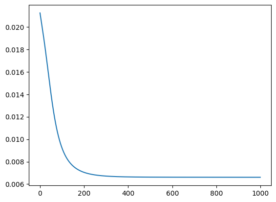

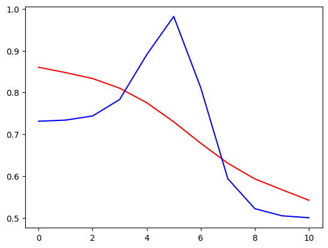

```
Weights of the network are:
w13, w12, w14 [[ 1.847739   -0.0644739   0.20371785]]
w35, w25, w45 [[-1.12331086  0.87973316  0.50597873]]
```

```python
##**Answer:**

import numpy as np

np.random.seed(42)

# defining the backprop for Sigmoid Function
def back_sigmoid(x):
    return x*(1-x)

# defining the Sigmoid Function
def sigmoid(x):
    return 1 / (1 + np.exp(-x))

def forward_pass(X, weights_input_hidden, weights_hidden_output):
    # Hidden layer linear combination: (N, 1) @ (1, 3) -> (N, 3)
    a_hidden = X @ weights_input_hidden # a_2, a_3, a_4

    # Hidden layer activation (Sigmoid): z_2, z_3, z_4
    hiddenLayer_activations = sigmoid(a_hidden)

    # Output layer linear combination: (N, 3) @ (3, 1) -> (N, 1)
    a_output = hiddenLayer_activations @ weights_hidden_output # a_1

    # Output layer activation (Sigmoid): z_1
    output = sigmoid(a_output) # z_1

    return output, hiddenLayer_activations # z_1, [z_2, z_3, z_4]


def backward_pass(X, y, output, weights_hidden_output, weights_input_hidden, hiddenLayer_activations):
    # calculating rate of change of error w.r.t weight between hidden and output layer

    # Output layer error (δ_1)
    delta_1 = (output - y) * back_sigmoid(output) # shape: (N, 1)

    # Gradient for output layer's weights
    # hiddenLayer_activation.T: (3, N), delta_1: (N, 1) -> error_wrt_weights_hidden_output: (3, 1)
    error_wrt_weights_hidden_output = hiddenLayer_activations.T @ delta_1 # δ_1 * z_2, z_3, z_4. z_i is like how much the neuron contributed to the output of the model.

    # Hidden layer errors (δ_2, δ_3, δ_4)
    # delta_1 @ weights_hidden_output.T: (N, 1) @ (1, 3) → (N, 3)
    delta_hidden = back_sigmoid(hiddenLayer_activations) * (delta_1 @ weights_hidden_output.T)

    # Gradient for hidden layer's weights
    # X.T: (1, N), delta_hidden: (N, 3) -> error_wrt_weights_input_hidden: (1, 3)
    error_wrt_weights_input_hidden = X.T @ delta_hidden

    return error_wrt_weights_hidden_output, error_wrt_weights_input_hidden


def train(X_train, y_train):

    # defining the model architecture
    inputLayer_neurons = 1  # number of neurons at input
    hiddenLayer_neurons = 3  # number of hidden layers neurons
    outputLayer_neurons = 1  # number of neurons at output layer

    # initializing weight
    weights_input_hidden = np.random.uniform(size=(inputLayer_neurons, hiddenLayer_neurons))
    weights_hidden_output = np.random.uniform(
        size=(hiddenLayer_neurons, outputLayer_neurons)
    )
    # defining the parameters
    lr = 0.1
    epochs = 1000

    losses =  []

    for ep in range(epochs):
        epoch_losses = []

        for i in range(X_train.shape[0]):
            x = X_train[i].reshape(1, 1)
            y = y_train[i].reshape(1, 1)

            output_, hiddenLayer_activations = forward_pass(x, weights_input_hidden, weights_hidden_output)

            loss = np.square(y - output_) / 2
            epoch_losses.append(loss.item())

            ## Backward Propagation
            error_wrt_weights_hidden_output, error_wrt_weights_input_hidden = backward_pass(x, y,
                                                                                            output_,
                                                                                            weights_hidden_output,
                                                                                            weights_input_hidden,
                                                                                            hiddenLayer_activations)
            # updating the weights
            weights_hidden_output -= lr * error_wrt_weights_hidden_output
            weights_input_hidden -= lr * error_wrt_weights_input_hidden

        avg_loss = np.mean(epoch_losses)
        losses.append(avg_loss)
        if ep % 100 == 0:
            print(f"Epoch {ep}: Loss = {avg_loss:.5f}")

    import matplotlib.pyplot as plt
    plt.plot(losses)
    plt.show()

    final_pred, _ = forward_pass(X_train, weights_input_hidden, weights_hidden_output)

    plt.plot(final_pred, c='r')
    plt.plot(y_train, c='b')
    plt.show()

    print("Weights of the network are: ")
    print("w13, w12, w14", weights_hidden_output.T)
    print("w35, w25, w45", weights_input_hidden)


# defining training data
X_train = np.zeros((11, 1)).astype(np.float32)
y_train = np.zeros((11, 1)).astype(np.float32)

X_train[0] = -3
X_train[1] = -2
X_train[2] = -1.5
X_train[3] = -1.0
X_train[4] = -0.5
X_train[5] = 0.0
X_train[6] = 0.5
X_train[7] = 1.0
X_train[8] = 1.5
X_train[9] = 2.0
X_train[10] = 3.0


y_train[0] = 0.7312
y_train[1] = 0.7339
y_train[2] = 0.7438
y_train[3] = 0.7832
y_train[4] = 0.8903
y_train[5] = 0.9820
y_train[6] = 0.8114
y_train[7] = 0.5937
y_train[8] = 0.5219
y_train[9] = 0.5049
y_train[10] = 0.5002


train(X_train, y_train)
```